# visiumStitched_brain

## Overview

This repository contains the data used to demonstrate the utility of [`visiumStitched`](https://github.com/LieberInstitute/visiumStitched). Three [Visium](https://www.10xgenomics.com/products/spatial-gene-expression) capture areas were collected from the postmortem human brain from one donor. We use [Fiji](https://imagej.net/software/fiji/) and `visiumStitched` to stitch the gene-expression and imaging data into one sample for downstream analysis.

If you tweet about this website, the data or the R package please use the `#visiumStitched` hashtag. You can find previous tweets that way as shown [here](https://twitter.com/search?q=%23visiumStitched&src=typed_query).

Thank you for your interest in our work!

## Internal

- JHPCE location: `/dcs05/lieber/lcolladotor/visiumStitched_LIBD1070/visiumStitched_brain`.

The code in this repository follows the organization from https://github.com/LieberInstitute/template_project following the guidelines from [organizing-your-work](https://lcolladotor.github.io/bioc_team_ds/organizing-your-work.html#.YzL43uzMKX0).

## Introductory Material

Check out [this guide](http://research.libd.org/visiumStitched/articles/full_demo.html) to using `visiumStitched`, which enabled the integration of all three capture areas for this project.

[video not shown]

## Interactive Websites

Explore the [Shiny app](https://libd.shinyapps.io/visiumStitched_brain), powered by [spatialLIBD](https://doi.org/10.1186/s12864-022-08601-w).

Alternatively, you may choose to run the app locally with [`spatialLIBD::run_app()`](http://research.libd.org/spatialLIBD/reference/run_app.html), which gives more freedom regarding memory usage and session length. See [this example](https://github.com/LieberInstitute/visiumStitched_brain/blob/devel/code/05_shiny/app.R) for invoking `spatialLIBD::run_app()` with an appropriate set of arguments.

## R Objects

The transcriptomics data, SpaceRanger outputs, and Fiji outputs are all available through `spatialLIBD::fetch_data()`. A comprehensive vignette using these objects is written [here](http://research.libd.org/visiumStitched/articles/full_demo.html).

```r
## Check that you have a recent version of spatialLIBD installed
stopifnot(packageVersion("spatialLIBD") >= "1.17.6")

## Download the spot-level data, which is a SpatialExperiment object
spe <- spatialLIBD::fetch_data(type = "visiumStitched_brain_spe")
```

```
#> snapshotDate(): 2024-04-29
#> 2024-07-26 18:02:25.588939 loading file /Users/leocollado/Library/Caches/org.R-project.R/R/BiocFileCache/154352e7328f0_visiumStitched_brain_spe.rds%3Frlkey%3Dnq6a82u23xuu9hohr86oodwdi%26dl%3D1
```

```r
spe
```

```
#> class: SpatialExperiment
#> dim: 26369 13965
#> metadata(0):
#> assays(2): counts logcounts
#> rownames(26369): ENSG00000238009 ENSG00000241860 ... ENSG00000278817 ENSG00000277196
#> rowData names(7): source type ... gene_type gene_search
#> colnames(13965): AAACAACGAATAGTTC-1_V13B23-283_A1 AAACAAGTATCTCCCA-1_V13B23-283_A1
#>   ... TTGTTTGTATTACACG-1_V13B23-283_D1 TTGTTTGTGTAAATTC-1_V13B23-283_D1
#> colData names(40): sample_id in_tissue ... precast_k4 precast_k8
#> reducedDimNames(1): PCA
#> mainExpName: NULL
#> altExpNames(0):
#> spatialCoords names(2) : pxl_col_in_fullres pxl_row_in_fullres
#> imgData names(4): sample_id image_id data scaleFactor
```

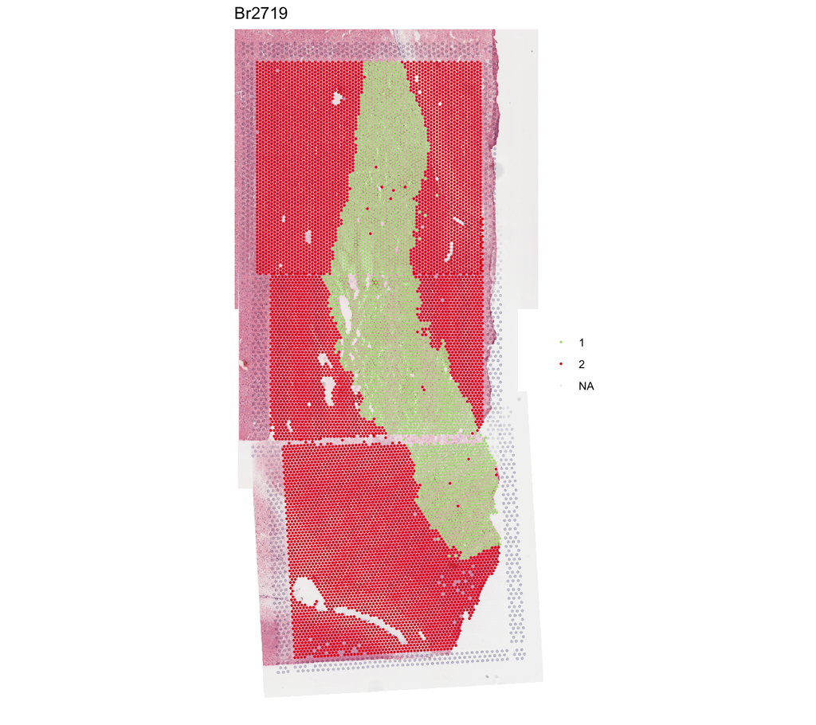

```r
## Show clustering results from PRECAST at k = 2
spatialLIBD::vis_clus(spe, clustervar = 'precast_k2', is_stitched = TRUE)
```

## Citing Our Work

### Cite `spatialLIBD`

Below is the citation output from using `citation('spatialLIBD')` in R. Please run this yourself to check for any updates on how to cite **spatialLIBD**.

```r
print(citation("spatialLIBD")[1], bibtex = TRUE)
```

```
#> Pardo B, Spangler A, Weber LM, Hicks SC, Jaffe AE, Martinowich K, Maynard KR,
#> Collado-Torres L (2022). "spatialLIBD: an R/Bioconductor package to visualize
#> spatially-resolved transcriptomics data." _BMC Genomics_.
#> doi:10.1186/s12864-022-08601-w <https://doi.org/10.1186/s12864-022-08601-w>,
#> <https://doi.org/10.1186/s12864-022-08601-w>.
#>
#> A BibTeX entry for LaTeX users is
#>
#>   @Article{,
#>     title = {spatialLIBD: an R/Bioconductor package to visualize spatially-resolved transcriptomics data},
#>     author = {Brenda Pardo and Abby Spangler and Lukas M. Weber and Stephanie C. Hicks and Andrew E. Jaffe and Keri Martinowich and Kristen R. Maynard and Leonardo Collado-Torres},
#>     year = {2022},
#>     journal = {BMC Genomics},
#>     doi = {10.1186/s12864-022-08601-w},
#>     url = {https://doi.org/10.1186/s12864-022-08601-w},
#>   }
```

Please note that `spatialLIBD` was only made possible thanks to many other R and bioinformatics software authors, which are cited either in the vignettes and/or the paper(s) describing the package.